# 从病例数据对比分析影响不同地区疫情的特征

Happy Beatles

2020/5/22

# 主要内容

- 绪论
- 病例数据对比分析
- 温州防控政策效果分析
- 后续工作

# 1、绪论

### 研究背景和目的

- 到目前为止，新冠病毒全球累计确诊人数已达到480万，部份国家的每日新增病例数也在逐日猛增，形势不容乐观。但值得庆幸的是，此次疫情在中国境内已经得到了有效的控制，虽然目前，部分地区出现“反弹”的情况，但专家预计国内不会再出现第二次疫情大流行的情况。这样显著的成果，是离不开政府强有力的疫情控制政策的。
- 在疫情初期，新冠病毒就迅速发展到了除湖北以外的其他省市，各个地区都受到了不同程度的影响。在没有疫苗的情况下，各地方所采取的防疫政策是控制疫情传播的最有效的方法，不同程度的防控政策也会对疫情的发展产生不同的影响，因此，本次研究旨探究疫情初期时的不同地区疫情发展的特点和差异，并重点分析防控政策对其疫情的影响。

# 深圳

- 本次我们选择研究的城市是深圳市和温州市。
- 深圳市作为在疫情初期最早接受世界卫生组织联合考察的城市之一，其防控政策和措施得到了很高的评价，并且深圳市还被作为唯一一个城市案例进行了分析。

[figure not shown]

- 图片来源：深圳卫视深视新闻

# 温州

- 浙江省温州市，距离湖北武汉市，直线距离900公里，截至1月29日，浙江省成为除湖北以外确诊病例第二多的省份，并且温州市成了除湖北四市以外的确诊病例最多的城市，仅次于武汉、黄冈、孝感、荆门，排名全国第五。
- 温州市一直是国内的人口流动大市，据官方统计，温州在武汉经商、就学和务工的人数达到18万，并且在湖北四市已实施“封城”措施后，温州市只是临时关闭了部分的高速路口。
- 部分媒体和专家认为，在全国关注武汉市及湖北省疫情的情况下，温州市的疫情也不容忽视，当前温州市得到的关注和重视是与其自身疫情不相匹配的。

# 参考文献

- [1]王学钦团队报告：从病例数据对比分析影响温州与深圳疫情的特征
- [2]刘友金，曾小明.房产税对产业转移的影响：来自重庆和 上海的经验证据
- [3]Alberto abadie,Alexis Diamond, and Jens Hainmueller.Synthetic Control Methods for Comparative Case Studies: Estimating the Effect of California’s Tobacco Control Program
- [4]连玉君.合成控制法 (Synthetic Control Method) 及 Stata实现

# 2、病例数据对比分析

- 数据来源：
  - 深圳市政府数据开放平台（https://opendata.sz.gov.cn/data/search/toSearch）
  - 温州市卫健委(http://wjw.wenzhou.gov.cn/)
- 时间：2020年1月27—2020年2月17日
- 地区：深圳市和温州市
- 病例特征：病例来源、性别、年龄

# 疫情发展趋势对比

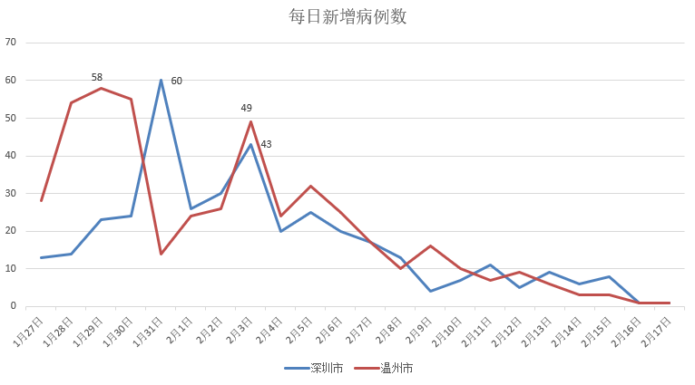

- 疫情发展趋势：低——高——低
- 新增确诊人数峰值
  - 深圳市：1月31日
  - 温州市：1月29日

# 病例来源分布

- 输入型病例：有湖北居旅史
- 非输入型病例：无湖北居旅史且居住地为本地

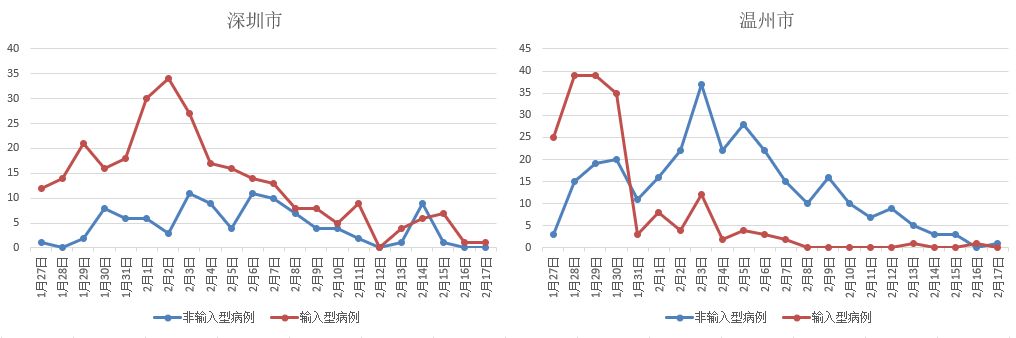

- 病例来源（每日新增病例）
  - 深圳市：主要是输入型病例
  - 温州市：1月31日前以输入型病例为主，1月31日之后以非输入型病例为主
- 卡方检验：深圳市和温州市的病例来源分布存在显著性差异
- p值=0.0001<0.05

# 输入型病例的传播强度

- 公式：传播强度=累计非输入性病例人数/累计输入型病例人数
- 表示了平均每个输入型病例造成非输入型病例感染的人数，即输入型病例的传播强度

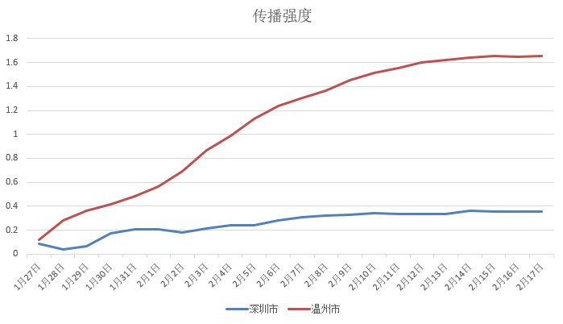

- 传播强度：
  - 疫情的传播途径：输入型病例到非输入型病例；非输入型病例到非输入型病例
  - 深圳市：虽然深圳市的输入型病例较多，但传播强度较小
  - 温州市：虽然温州市输入型病例在早期得到控制，但传播强度较大

# 性别分布

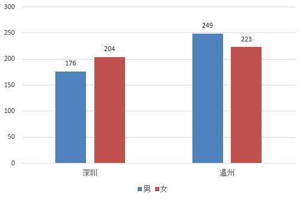

- 深圳市：女性病例多于男性病例
- 温州市：男性病例多于女性病例

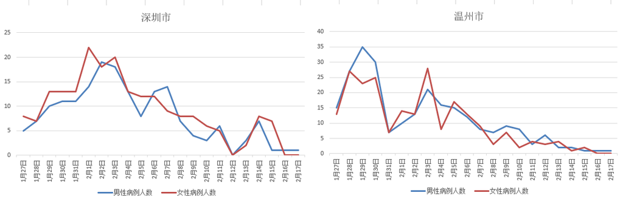

- 从病例性别的每日新增病例数来看，两市男性和女性病例的变化趋势基本一致且比例也无明显变化
- 卡方检验：没有足够理由认为温州市和深圳市的病例在性别比例上有显著差异
- p值=0.067>0.05

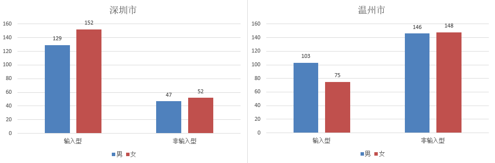

- 深圳市:
  - 卡方检验：没有足够理由认为病例性别比例与病例来源之间有显著性差异
  - p=0.788>0.05
- 温州市
  - 卡方检验：没有足够理由认为病例性别比例与病例来源之间有显著性差异
  - p=0.089>0.05

# 年龄分布

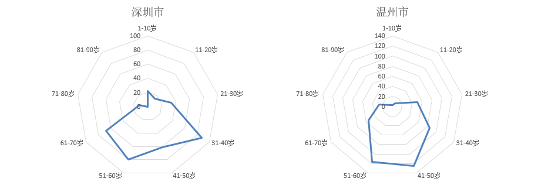

- 深圳市：病例主要集中在51-60岁和31-40岁
- 温州市：病例主要集中在51-60岁和41-50岁
- 卡方检验:深圳市和温州市的病例年龄段分布存在显著性差异
- p=0.0001<0.05

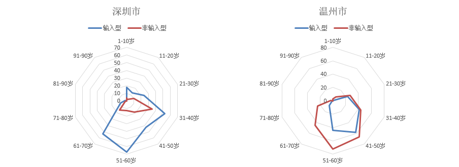

- 深圳市：
  - 输入型病例：病例主要集中在51-60岁
  - 非输入型病病例：病例主要集中在31-40岁
- 卡方检验：深圳市的病例年龄与病例来源之间存在显著性差异
- p=0.03<0.05
- 温州市：
  - 输入型病例：主要集中在41-50岁
  - 非输入型病例：主要集中在41-50岁和51-60岁
- 卡方检验：温州市的病例年龄与病例来源之间存在显著性差异
- p=0.0001<0.05
- 解释：
  - 深圳市：移民城市；输入人群多为中老年人群（51-70岁）
  - 温州市：务工返乡；输入人群多为中青年人群（40岁左右）

# 3、温州防疫政策效果评价

- 温州疫情情况
- 温州防疫政策
- 合成控制法回顾
- donor pool选择
- 温州防疫政策效果评价
- 后续工作

# 温州疫情情况

千里之外的温州，为何会成为疫情的重灾区？

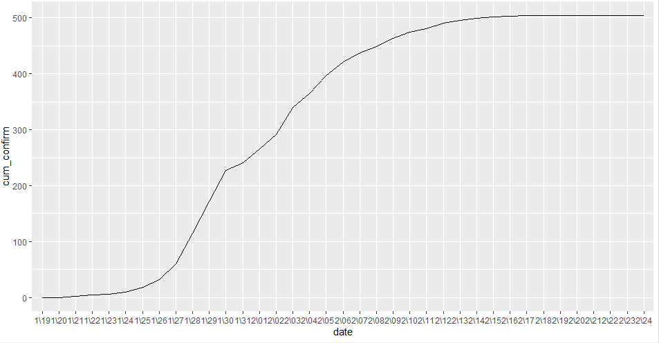

为何温州新冠肺炎感染人数如此之多？

- 在武汉的温州人数量庞大
- 温州的地方人情往来繁多
- 疫情初期防控意识淡薄
- 与外界交往频繁

# 温州防控政策

- 1月23日：设立武汉航班专用停机位和疑似病人留观点，对从武汉到达的旅客全部实行体温检测。
- 1月27日：全面暂停省际班车客运、包车客运和市际班线、包车客运；宾馆、商场等人员密集场所全部停用中央空调。
- 1月28日：加强风险源管控，建立“一对一”跟踪管控制度。
- 2月01日：**市区公交暂停运营**，临时关闭46个告诉收费站，**小区实施封闭式管理**，每户每两天可指派1名家庭成员出门采购生活物资；另外，温州多个下属地区发布有奖举报公告，规定民众举报一名从疫区到温州的人员，核实后可获得1000元人民币奖励。
- 2月09日：对拒不听从工作人员管理劝阻、聚众闹事的，公安机关加大打击力度。

# 合成控制法回顾

### 基本思想

在很多研究中，政策干预的个体仅有一个，如何科学地评价政策干预对该个体的影响？  
尽管控制组中的任何个体与干预个体都不相似，但是通过为每个控制组个体赋予一个权重，构造出一个合成的控制组。权重的选择使得合成控制法的行为与干预组政策干预之前的行为非常相似，从而期望事后干预组如果没有受到政策干预，其行为仍然与合成控制组非常相似，即合成控制法事后的结果可以作为干预组个体的反事实结果，干预组和合成控制组事后结果的差异就是政策干预的影响。

### SCM的操作步骤

1、筛选合适的控制组，确定合理的预测变量；

2、拟合一个适宜的反事实合成组；

3、对比合成组与处理组的差异以评估政策冲击的影响；

4、安慰剂检验

# donor pool选择

### 思路介绍

- 选定初始控制组为除自治区、特别行政区、台湾之外的268个城市，但是这些城市与温州的相似程度差别有大有小，且预测变量和结果变量数据的搜集和分析难度较大。
- 故在实施合成控制法之前需要根据各城市的地区生产总值、人口密度、以及1月31号的累计确诊病例数三个变量通过K-means聚类筛选出与温州相似度较高的城市。

### 聚类方法介绍

- k-means聚类方法是划分方法中较经典的聚类算法之一。由于该算法的效率高，所以在对大规模数据进行聚类时被广泛应用。
- k-means算法以k为参数，把n个对象分成k个簇，使簇内具有较高的相似度，而簇间的相似度较低。具体思路如下：
- 首先，随机地选择k个对象，每个对象初始地代表了一个簇的平均值或中心。
- 对剩余的每个对象，根据其与各簇中心的距离，将它赋给最近的簇。
- 然后重新计算每个簇的平均值。
- 这个过程不断重复，直到准则函数收敛。

### 确定聚类数目

- 用最简单的指标组内平方和sum of squared error (SSE)来确定最佳聚类数目。
- 随着聚类数目增多，每一个类别中数量越来越少，距离越来越近，SSE值随着聚类数目增多而减少，所以要关注斜率的变化。但当SSE值减少的很缓慢时，就认为进一步增大聚类数，效果也并不能增强，存在的这个“肘点”就是最佳聚类数目。
- 计算出聚类数目分别为1-10的SSE值，画出拐点图。

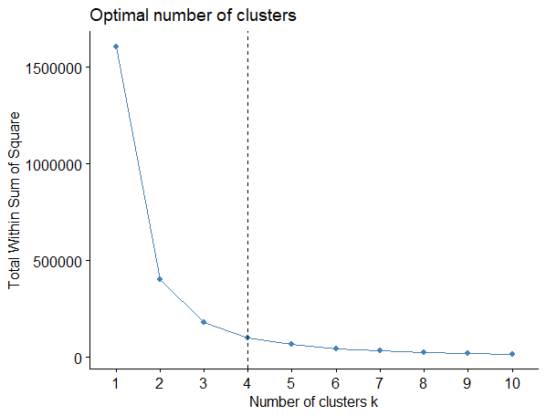

SSE的拐点图

### 聚类结果分析

- 每个聚类中的个案数目结果如下：

| 类别 | 数目 |
| --- | --- |
| 1 | 160 |
| 2 | 18 |
| 3 | 29 |
| 4 | 61 |
| 有效 | 268 |
| 缺失 | 0 |

- 我们要进行温州地区的疫情研究，温州被聚到了第3类，这一类有29个地区。我们选取除温州外的28个地区作为合成控制法的控制组，分别是：  
  沈阳、抚顺、南京、无锡、徐州、苏州、宿迁、杭州、宁波、舟山、丽水、天门、黄山、三亚、三明、南昌、上饶、济南、东营、三门峡、汕尾、宜昌、荆门、荆州、新余、汕头、商丘、揭阳。

# 温州政策效应评价

### 主要变量

- 结果变量：发病率（每十万人确诊率）
- 预测变量：lnGDP
- 预测变量：ln人口密度
- 预测变量：累计确诊人数

### 各地区最优权重表

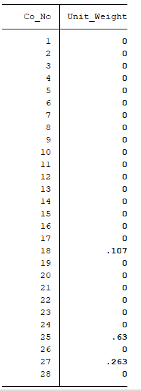

### 合成温州与真实温州对比

| Variable | Treated | Synthetic |
| --- | --- | --- |
| lnGDP | 8.700541 | 8.832305 |
| ln人口密度 | 7.867075 | 8.027493 |
| 累计确诊人数 | 68.15385 | 69.05769 |
| 发病率(1/24) | 0.107527 | 0.107632 |
| 发病率(1/24) | 2.440860 | 2.440913 |

### SCM的效果

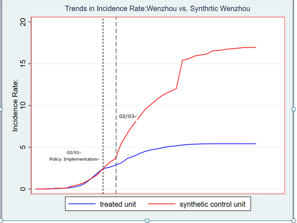

### 政策处理效应

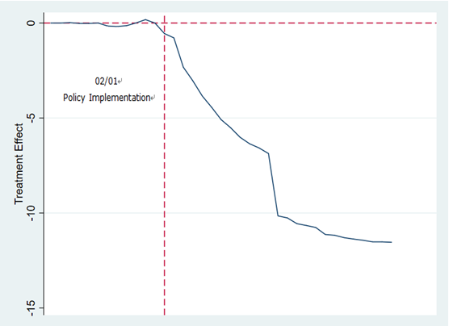

### 安慰剂检验

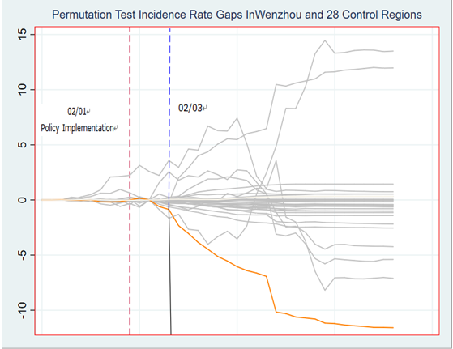

**结论：**温州的防疫政策对于发病率的降低有显著的作用。

# 后续工作

- 深圳的防疫政策效果评价
- 政策延迟效应分析
- 全球疫情政策研究